# R Notebook

```r
#install.packages("ggplot2")
library(foreign)
library(ggplot2)
library(plyr)
```

```r
#hogares (homes)
#Reading the .sav file (SPSS)
directory <- "C:/OneDrive/2018/_CSP572_Practicum/EDSA UCA/"
hogares.filename <- "Base EDSA hogares 2010.Difusión (V.BETA).sav"
hogares <- read.spss(paste0(directory,hogares.filename))
```

```
re-encoding from CP1252
```

```r
hogares.attr<-attributes(hogares)
hogares.df <- read.spss(paste0(directory,hogares.filename),to.data.frame = T)
```

```
re-encoding from CP1252
```

```r
#str(hogares.df)
#Writing data into a CSV
#write.csv(hogares.df,file="homes_data.csv")
```

`r`r ggplot(hogares.df[1], aes(ENCUESTA)) + stat_count()

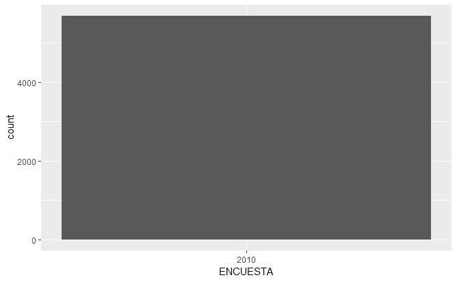

[figure not shown]

`r`r #The first two fields don’t contain useful information hogares.clean <- hogares.df[-c(1,2)]

`r`r str(hogares.clean)

```
'data.frame':   5653 obs. of  77 variables:
 $ PON_HOG                         : num  2487 3227 2798 2967 1153 ...
 $ PON_TOT                         : num  2487 3227 2798 2967 1153 ...
 $ PON_SIN_ELEVAR                  : num  2.29 2.97 2.57 2.73 1.06 ...
 $ PON_SIN_ELEVAR_TOT              : num  1.288 1.671 1.449 1.537 0.597 ...
 $ EST_CLASE_7                     : Factor w/ 7 levels \E\,\D2 - \,\D1\,..: 5 4 6 6 4 7 3 4 6 4 ...
 $ EST_CLASE_6                     : Factor w/ 6 levels \E\,\D2\,\D1\,..: 5 4 6 6 4 6 3 4 6 4 ...
 $ EST_CLASE_4                     : Factor w/ 4 levels \Clase media profesional\,..: 1 2 1 1 2 1 3 2 1 2 ...
 $ NIV_SOCIO_4                     : Factor w/ 4 levels \Medio Alto\,\Medio Bajo\,..: 1 1 1 1 1 1 2 1 1 1 ...
 $ NIV_SOCIO_5                     : num  5 5 5 5 5 5 4 5 5 5 ...
 $ NIV_SOCIO_6                     : num  10 9 10 10 10 10 8 10 10 10 ...
 $ AGLOM_1                         : Factor w/ 2 levels \Gran Buenos aires\,..: 1 1 1 1 1 1 1 1 1 1 ...
 $ AGL_URBAN_4                     : Factor w/ 4 levels \Ciudad de Buenos Aires\,..: 2 2 2 2 2 2 2 2 2 2 ...
 $ Region                          : Factor w/ 6 levels \AMBA\,\NOA\,\NEA\,..: 1 1 1 1 1 1 1 1 1 1 ...
 $ CON_RESID_4                     : Factor w/ 4 levels \NSE Medio Alto\,..: 1 1 1 1 1 1 1 1 1 1 ...
```

[output cut: 53 more lines]

[figure not shown]

`r`r #hogares.clean$PON_HOG field.nr <- 2 ggplot(hogares.clean[field.nr], aes(hogares.clean[[field.nr]])) + geom_histogram(bins = 50)+ggtitle(names(hogares.clean[field.nr]))

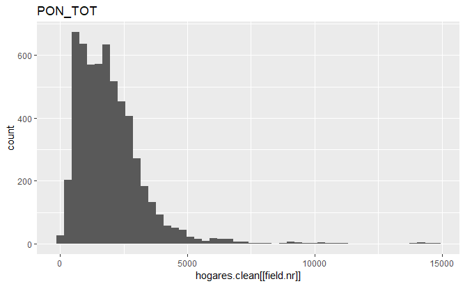

`r`r #hogares.clean field.nr <- 3 ggplot(hogares.clean[field.nr], aes(hogares.clean[[field.nr]])) + geom_histogram(bins = 50)+ggtitle(names(hogares.clean[field.nr]))

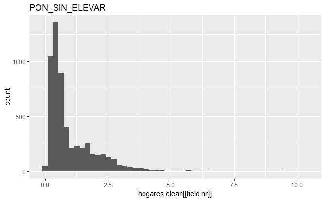

`r`r #hogares.clean field.nr <- 4 ggplot(hogares.clean[field.nr], aes(hogares.clean[[field.nr]])) + geom_histogram(bins = 50)+ggtitle(names(hogares.clean[field.nr]))

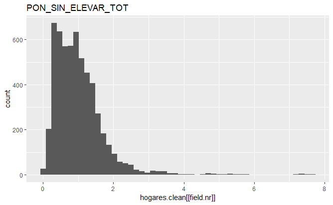

[figure not shown]

`r`r #hogares.clean field.nr <- 6 ggplot(hogares.clean[field.nr], aes(hogares.clean[[field.nr]])) + stat_count()+ggtitle(names(hogares.clean[field.nr]))

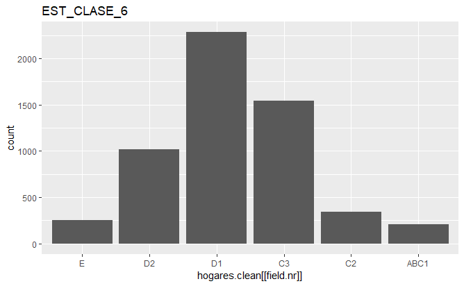

`r`r #hogares.clean field.nr <- 7 ggplot(hogares.clean[field.nr], aes(hogares.clean[[field.nr]])) + stat_count()+ggtitle(names(hogares.clean[field.nr]))

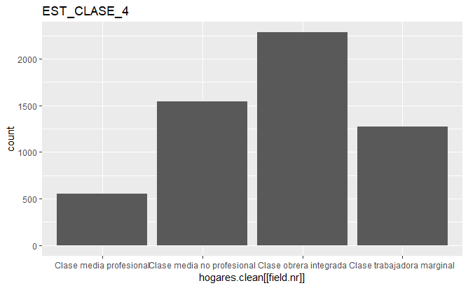

`r`r #hogares.clean field.nr <- 8 ggplot(hogares.clean[field.nr], aes(hogares.clean[[field.nr]])) + stat_count()+ggtitle(names(hogares.clean[field.nr]))

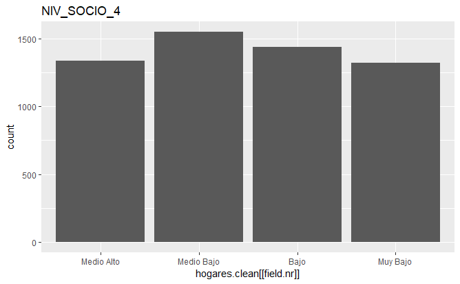

`r`r #hogares.clean field.nr <- 9 ggplot(hogares.clean[field.nr], aes(hogares.clean[[field.nr]])) + stat_count()+ggtitle(names(hogares.clean[field.nr]))

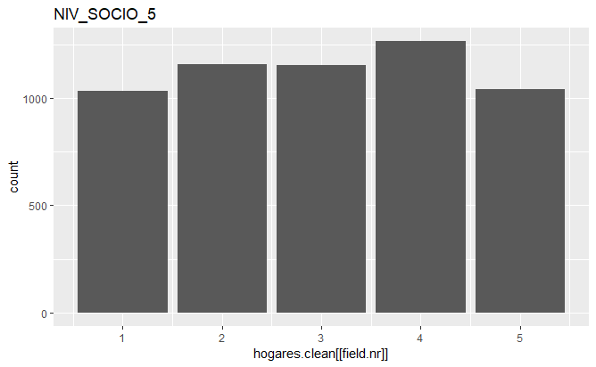

`r`r #hogares.clean field.nr <- 10 ggplot(hogares.clean[field.nr], aes(hogares.clean[[field.nr]])) + stat_count()+ggtitle(names(hogares.clean[field.nr]))

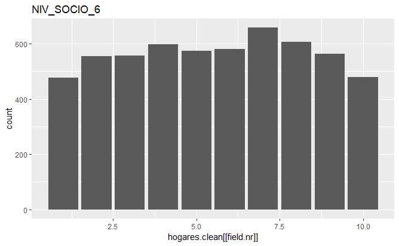

`r`r #hogares.clean field.nr <- 11 ggplot(hogares.clean[field.nr], aes(hogares.clean[[field.nr]])) + stat_count()+ggtitle(names(hogares.clean[field.nr]))

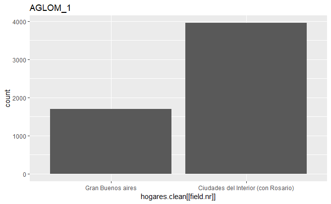

`r`r #hogares.clean field.nr <- 12 ggplot(hogares.clean[field.nr], aes(hogares.clean[[field.nr]])) + stat_count()+ggtitle(names(hogares.clean[field.nr]))

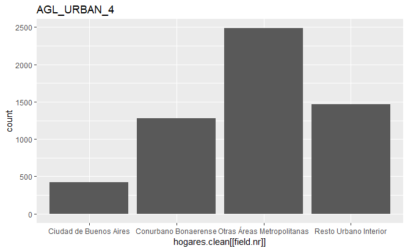

`r`r #hogares.clean field.nr <- 13 ggplot(hogares.clean[field.nr], aes(hogares.clean[[field.nr]])) + stat_count()+ggtitle(names(hogares.clean[field.nr]))

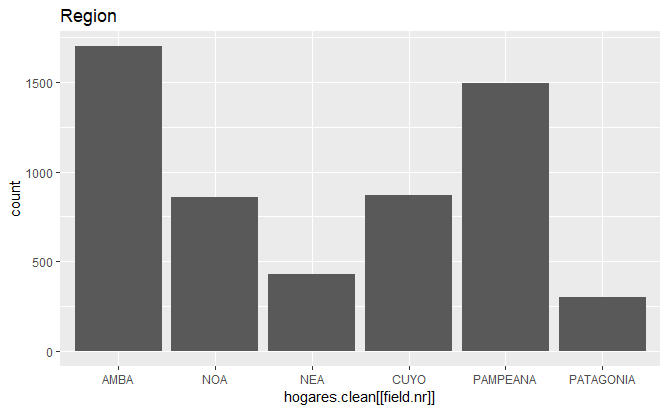

`r`r #hogares.clean field.nr <- 14 ggplot(hogares.clean[field.nr], aes(hogares.clean[[field.nr]])) + stat_count()+ggtitle(names(hogares.clean[field.nr]))

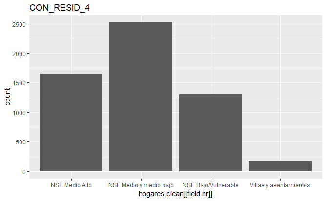

`r`r #hogares.clean field.nr <- 15 ggplot(hogares.clean[field.nr], aes(hogares.clean[[field.nr]])) + stat_count()+ggtitle(names(hogares.clean[field.nr]))

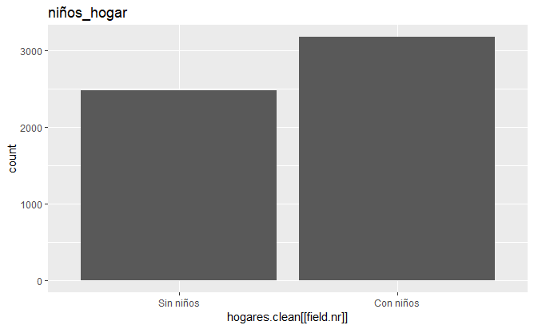

`r`r #hogares.clean field.nr <- 16 ggplot(hogares.clean[field.nr], aes(hogares.clean[[field.nr]])) + stat_count()+ggtitle(names(hogares.clean[field.nr]))+ theme(axis.text.x = element_text(angle = 30, hjust = 1))

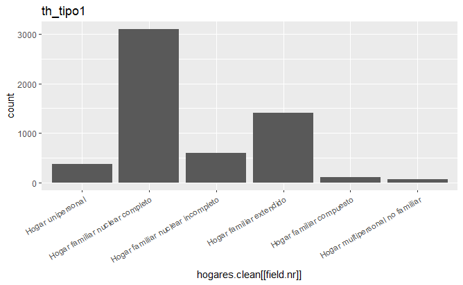

`r`r #hogares.clean field.nr <- 17 ggplot(hogares.clean[field.nr], aes(hogares.clean[[field.nr]])) + stat_count()+ggtitle(names(hogares.clean[field.nr]))+ theme(axis.text.x = element_text(angle = 45, hjust = 1))

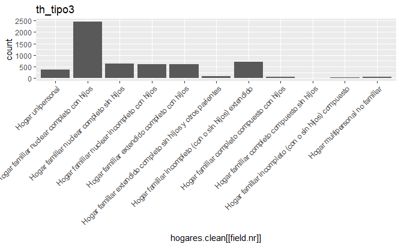

`r`r #hogares.clean field.nr <- 18 ggplot(hogares.clean[field.nr], aes(hogares.clean[[field.nr]])) + stat_count()+ggtitle(names(hogares.clean[field.nr]))+ theme(axis.text.x = element_text(angle = 30, hjust = 1))

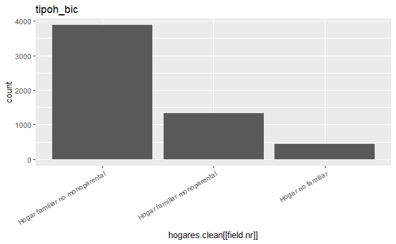

`r`r #hogares.clean field.nr <- 19 ggplot(hogares.clean[field.nr], aes(hogares.clean[[field.nr]])) + stat_count()+ggtitle(names(hogares.clean[field.nr]))+ theme(axis.text.x = element_text(angle = 30, hjust = 1))

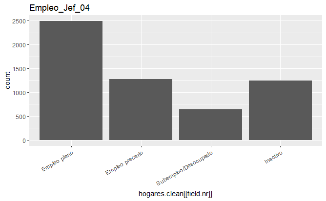

`r`r #hogares.clean field.nr <- 20 ggplot(hogares.clean[field.nr], aes(hogares.clean[[field.nr]])) + stat_count()+ggtitle(names(hogares.clean[field.nr]))+ theme(axis.text.x = element_text(angle = 30, hjust = 1))

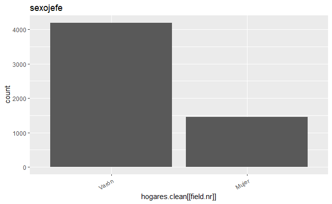

`r`r #hogares.clean field.nr <- 21 ggplot(hogares.clean[field.nr], aes(hogares.clean[[field.nr]])) + stat_count()+ggtitle(names(hogares.clean[field.nr]))+ theme(axis.text.x = element_text(angle = 30, hjust = 1))

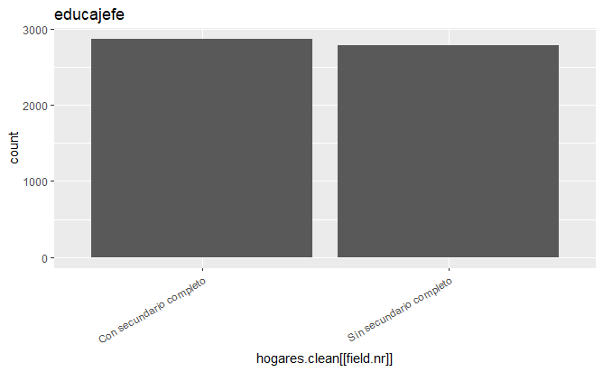

`r`r #hogares.clean field.nr <- 22 data.gr <- hogares.clean[field.nr] ggplot(data.gr, aes(data.gr[[1]],fill=data.gr[[1]])) + stat_count()+ggtitle(names(hogares.clean[field.nr]))+ theme(axis.text.x = element_text(angle = 30, hjust = 1))

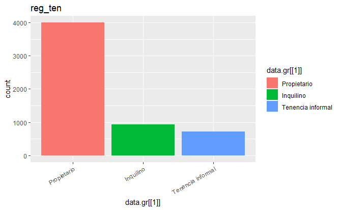

`r`r ggplot(lack.count[c(1:16),], aes(fill=Var1, y=Freq, x=param)) + geom_bar(position=, stat=)+coord_flip()

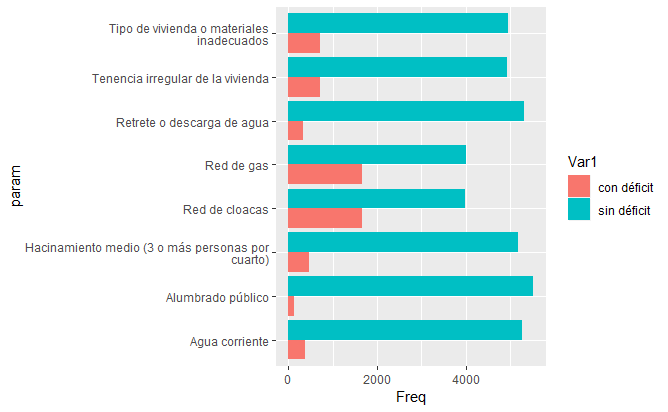

`r`r ggplot(lack.count[c(17:32),], aes(fill=Var1, y=Freq, x=param)) + geom_bar(position=, stat=)+coord_flip()

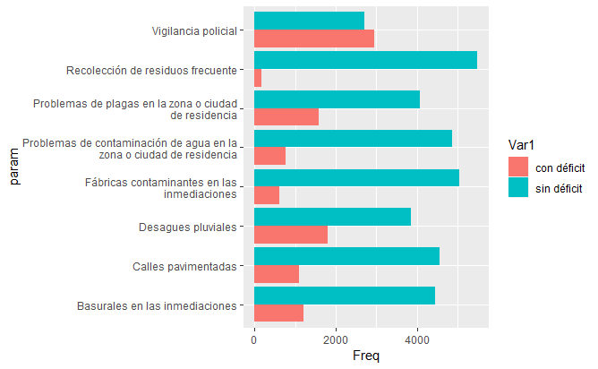

`r`r ggplot(lack.count[c(33:48),], aes(fill=Var1, y=Freq, x=param)) + geom_bar(position=, stat=)+coord_flip()

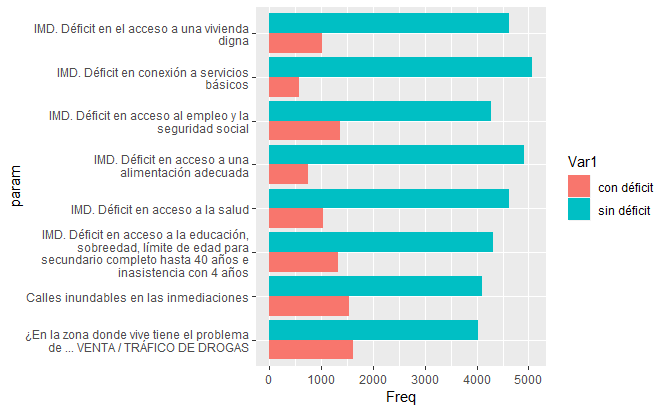

`r`r #hogares.clean field.nr <- 49 data.gr <- hogares.clean[field.nr] ggplot(data.gr, aes(data.gr[[1]])) + geom_histogram(fill=,color=)+ggtitle(names(hogares.clean[field.nr]))

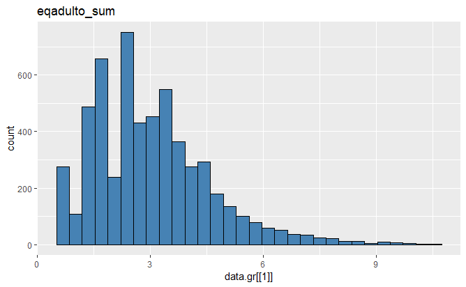

`r`r field.nr <- 50 data.gr <- hogares.clean[field.nr] ggplot(data.gr, aes(data.gr[[1]])) + stat_count(fill=,color=)+ggtitle(names(hogares.clean[field.nr]))

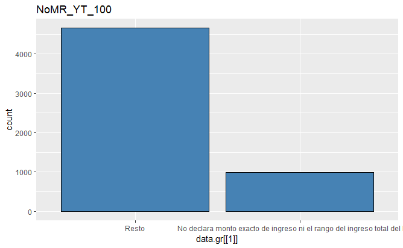

`r`r field.nr <- 51 data.gr <- hogares.clean[field.nr] ggplot(data.gr, aes(data.gr[[1]])) + geom_histogram(bins = 50,fill=,color=)+ggtitle(names(hogares.clean[field.nr]))

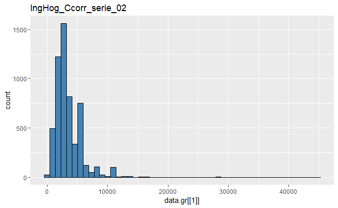

`r`r #Same plot excluding outliers field.nr <- 51 data.gr <- hogares.clean[field.nr] ggplot(data.gr, aes(data.gr[[1]])) + geom_histogram(bins = 50,fill=,color=)+ggtitle(names(hogares.clean[field.nr]))+ xlim(0, 17000)

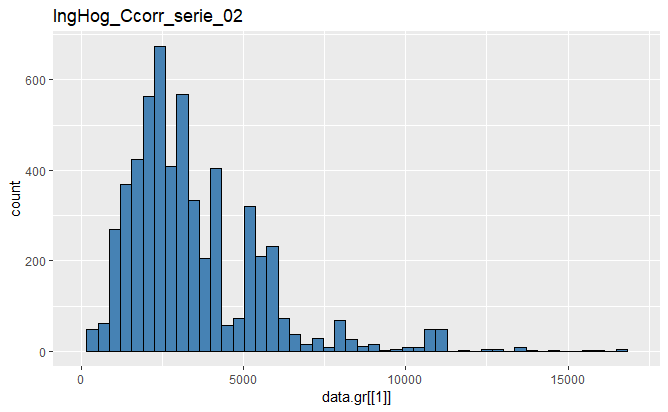

`r`r field.nr <- 52 data.gr <- hogares.clean[field.nr] ggplot(data.gr, aes(data.gr[[1]])) + geom_histogram(bins = 50,fill=,color=)+ggtitle(names(hogares.clean[field.nr]))+ xlim(0, 11000)

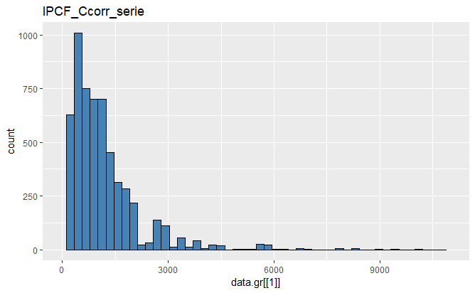

`r`r field.nr <- 53 data.gr <- hogares.clean[field.nr] ggplot(data.gr, aes(data.gr[[1]])) + geom_histogram(bins = 50,fill=,color=)+ggtitle(names(hogares.clean[field.nr]))+xlim(0, 12000)

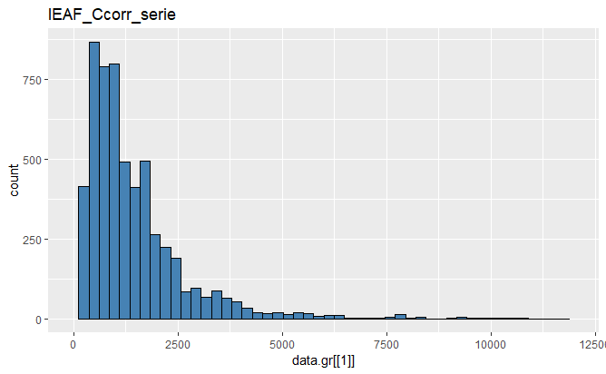

`r`r field.nr <- 54 data.gr <- hogares.clean[field.nr] ggplot(data.gr, aes(data.gr[[1]])) + stat_count(fill=,color=)+ggtitle(names(hogares.clean[field.nr]))

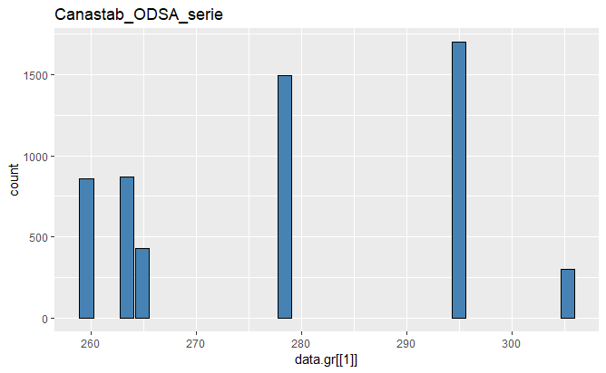

`r`r field.nr <- 55 data.gr <- hogares.clean[field.nr] ggplot(data.gr, aes(data.gr[[1]])) + stat_count(fill=,color=)+ggtitle(names(hogares.clean[field.nr]))

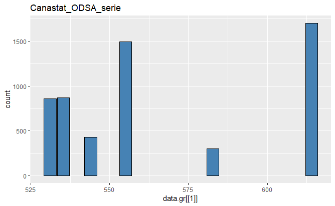

`r`r field.nr <- 56 data.gr <- hogares.clean[field.nr] ggplot(data.gr, aes(data.gr[[1]])) + stat_count(fill=,color=)+ggtitle(names(hogares.clean[field.nr]))